# Clustering ASVs

**Data Handling**

```r
library(dplyr) ; library(tidyr) ; library(ggplot2)
library(doParallel) ; library(foreach) ; library(doSNOW)

root <- rprojroot::has_file(".git/index")
datadir = root$find_file("data")
funsdir = root$find_file("functions")
savingdir = root$find_file("saved_files")

datapath = root$find_file(paste0(datadir,'/','grump.phaeocystis_asv_long.csv'))
files_vec <- list.files(funsdir)

for( i in 1:length(files_vec)){
  source(root$find_file(paste0(funsdir,'/',files_vec[i])))
}

funcitons_parallel = c("clusterize_ward_pam",
                       "eval_adist_clustering",
                       "inducedDist",
                       "summarise_adist_clustering",
                       "tidy_grump")

dframe = data.table::fread(input = datapath)
dframe = tidy_grump(Dframe = dframe)
```

**splitting inducer distance matrix**

The idea is to create a ‘custom’ distance matrix, to induce the grouppings.

- $c_1$ is within the same species - but no unassigned
- $c_2$ is between assigned species
- $c_3$ is between species and unassigned
- $c_4$ is within unassigned and unassigned

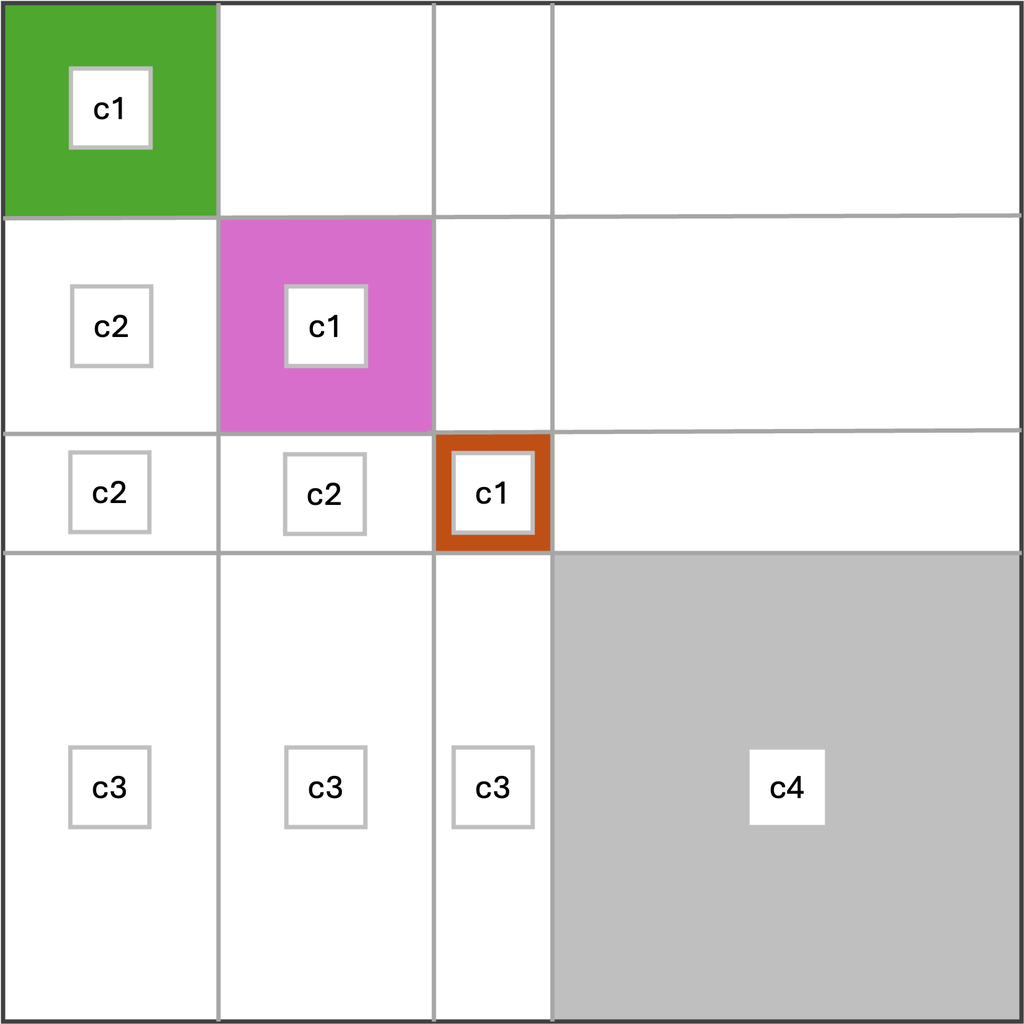

For this document we will use only the following configuration:

$c_1=1$, $c_2=1000$, $c_3=10$ , $c_4=10$

A priori, the ’probability` of unassigned ASVs to agglomerate between themselves is the same as if it was to agglomerate with other species. Large $c_2$ makes it harder for known species ASVs to group between themselves.

```r
inducedDist_ = inducedDist(
  dFrame = dframe$dframe,
  c1 = 1,c2=1000,c3=10,c4=10,
  compMatrix = dframe$ASV_composition)

#inducedDist$myDist_checking
```

**Metrics**

**Proposed**

$$S = \frac{numerator}{denominator}$$

Where:

$$numerator = \frac{1}{k} \left( \sum_{j=1}^{k} \left[ \frac{1}{n_j}\sum_{i}^{n_j} d(x_i-\bar x^{(j)} ) \right] \right)$$

The mean average distance within clusters (each observation and the medoid of the cluster)

$$denominator = \frac{1}{\binom{k}{2}} \sum_{i \neq j } d( \bar x^{(i)}-\bar x^{(j)} )$$

The average distance between clusters (each cluster is represented by it’s medoid)

**Permanova**

$$S = \frac{numerator}{denominator}$$

Where:

$$SS_T = \frac{1}{N} \sum_{i=1}^{N-1} \sum_{j=i+1}^{N-1} d^2_{ij}$$

Being $d^2_{ij}$ is the squared distance between objects $i$ and $j$.

$$SS_W = \frac{1}{n} \sum_{i=1}^{N-1} \sum_{j=i+1}^{N-1} d^2_{ij}\delta^2_{ij}$$

$\delta^2_{ij}$ is an indicator function (1 if obs$i$ and $j$ are from the same cluster, 0 otherwise). $SS_A$ Then difference between the overall and the within groups sum-of-squares ($SS_{A}=SS_{T}-SS_{W}$).

$$F = \frac{\frac{SS_{A}}{p-1}}{\frac{SS_{W}}{N-p}}$$

**New metric**

The idea of the new metric is: what if we represent the heterogeneity of a cluster by its maximum distance. Therefore, the average maximum distance within tends to decrease as the number of cluster increases.

Lets call this metric $T$.

$$T = \frac{\frac{1}{k}\sum_{(i,j)\in k}\max(d(x_i,x_j))}
{\frac{1}{k}\sum_{(i,j)\notin k}\min(d(x_i,x_j))}$$

**Creating the clusters**

```r
running=F

if(running){
  ## pure biotic factors =
  list_with_clusters_alpha0 <- clusterize_ward_pam(
    distMatrix = inducedDist_$normalizedAitDist,
    maxnclust = 50,
    dFrameAsv = dframe$ASV_composition$name)

  alpha_=0.1

  distMatrix_ = alpha_*inducedDist_$normalizedMyDist+(1-alpha_)*inducedDist_$normalizedAitDist

  list_with_clusters_alpha0.10 <- clusterize_ward_pam(
    distMatrix = distMatrix_,
    maxnclust = 50,
    dFrameAsv = dframe$ASV_composition$name)

  alpha_=0.25

  distMatrix_ = alpha_*inducedDist_$normalizedMyDist+(1-alpha_)*inducedDist_$normalizedAitDist

  list_with_clusters_alpha0.25 <- clusterize_ward_pam(
    distMatrix = distMatrix_,
    maxnclust = 50,
    dFrameAsv = dframe$ASV_composition$name)

  alpha_=0.5

  distMatrix_ = alpha_*inducedDist_$normalizedMyDist+(1-alpha_)*inducedDist_$normalizedAitDist

  list_with_clusters_alpha0.50 <- clusterize_ward_pam(
    distMatrix = distMatrix_,
    maxnclust = 50,
    dFrameAsv = dframe$ASV_composition$name)

  saveRDS(object = list_with_clusters_alpha0,file = paste0(savingdir,'/','list_with_clusters_alpha0'))
  saveRDS(object = list_with_clusters_alpha0.10,file = paste0(savingdir,'/','list_with_clusters_alpha0.10'))
  saveRDS(object = list_with_clusters_alpha0.25,file = paste0(savingdir,'/','list_with_clusters_alpha0.25'))
  saveRDS(object = list_with_clusters_alpha0.50,file = paste0(savingdir,'/','list_with_clusters_alpha0.50'))
}

list_with_clusters_alpha0 = readRDS(file = paste0(savingdir,'/','list_with_clusters_alpha0'))
list_with_clusters_alpha0.10 = readRDS(file = paste0(savingdir,'/','list_with_clusters_alpha0.10'))
list_with_clusters_alpha0.25 = readRDS(file = paste0(savingdir,'/','list_with_clusters_alpha0.25'))
list_with_clusters_alpha0.50 = readRDS(file = paste0(savingdir,'/','list_with_clusters_alpha0.50'))
```

**Calculating Metrics**

**hclust**

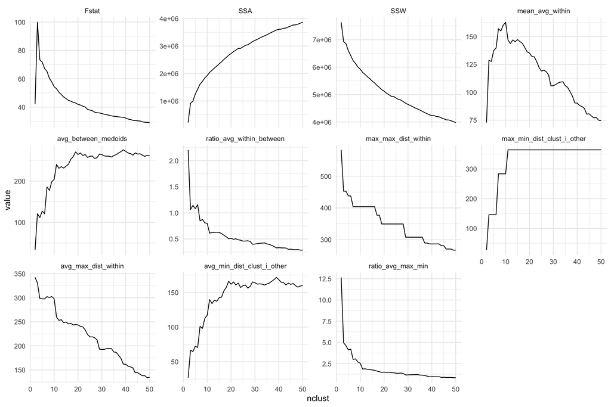

```r
running = F

if(running){
  nclusters <- ncol(list_with_clusters_alpha0$dFrameAsv_hclust)-1
  list_results <- list()

  for( i in 1:nclusters){
    list_results[[i]] <-  eval_adist_clustering(compositionDF = left_join(
      list_with_clusters_alpha0$dFrameAsv_hclust[,c(1,i+1)] %>% rename('name'=1,'Cluster'=2),
      dframe$ASV_composition))
    cat('iteration------:',i,'\n')
  }
  saveRDS(list_results,file = paste0(savingdir,'/','list_results_eval_alpha0_hclust'))
}

list_results_eval_alpha0_hclust = readRDS(paste0(savingdir,'/','list_results_eval_alpha0_hclust'))

summarise_adist_clustering(list_results_eval_alpha0_hclust) %>%
  reshape2::melt(id.vars = "nclust") %>%
  filter(nclust > 1) %>%
  ggplot(aes(x = nclust, y = value, group = variable)) +
    geom_line() +
    theme_minimal(base_size = 12) +
    facet_wrap(~variable, scales = "free_y")
```

**pam**

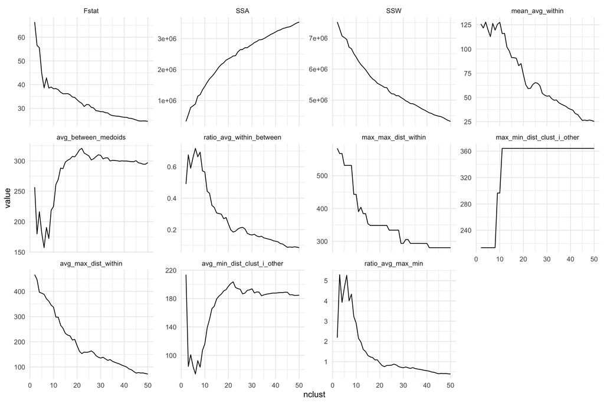

```r
running =F

if(running){
  nclusters <- ncol(list_with_clusters_alpha0$dFrameAsv_pam)-1
  list_results <- list()

  for( i in 1:nclusters){
    list_results[[i]] <-  eval_adist_clustering(compositionDF = left_join(
      list_with_clusters_alpha0$dFrameAsv_pam[,c(1,i+1)] %>% rename('name'=1,'Cluster'=2),
      dframe$ASV_composition))
    cat('iteration------:',i,'\n')
  }
  saveRDS(list_results,file = paste0(savingdir,'/','list_results_eval_alpha0_pam'))
}

list_results_eval_alpha0_pam = readRDS(paste0(savingdir,'/','list_results_eval_alpha0_pam'))

summarise_adist_clustering(list_results_eval_alpha0_pam) %>%
  reshape2::melt(id.vars = "nclust") %>%
  filter(nclust > 1) %>%
  ggplot(aes(x = nclust, y = value, group = variable)) +
    geom_line() +
    theme_minimal(base_size = 12) +
    facet_wrap(~variable, scales = "free_y")
```

**Splitting and Evaluating Metrics**

**Alpha = 0**

**Proposed Metrics**

For $\alpha = 0$

```r
running = F
if (running){
set.seed(1234)
alpha0_bootstrap = finding_optimal_k_parallel(
  dframe_asv = dframe$dframe %>% select(SampleKey,ASV_name,Raw.Sequence.Counts),
  B = 100,split_pct = 0.5,maxnclust_ = 50,vec_functions_fromEnv = funcitons_parallel)
  saveRDS(alpha0_bootstrap,file = paste0(savingdir,'/','alpha0_bootstrap'))
}
```

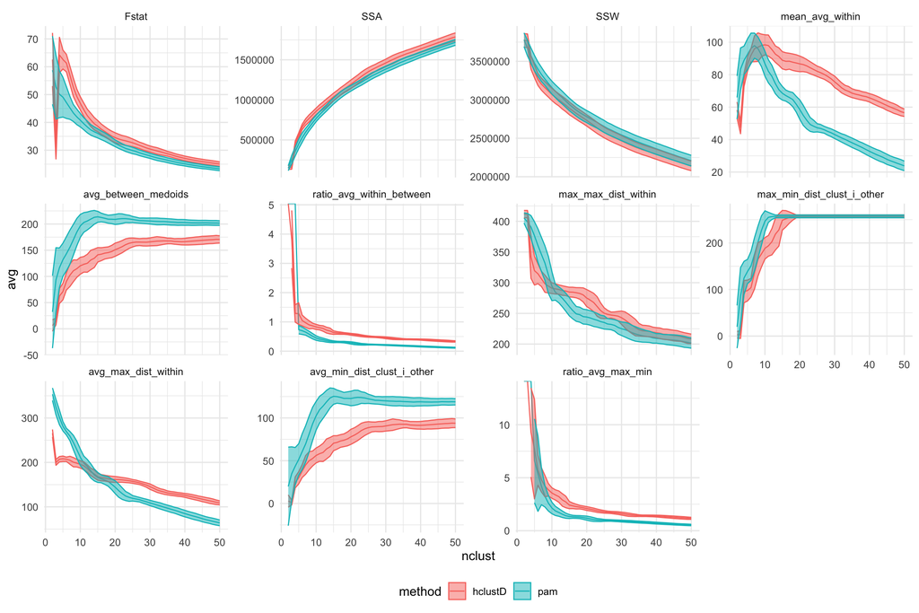

```r
alpha0_bootstrap_df = readRDS(paste0(savingdir,'/','alpha0_bootstrap'))
alpha0_bootstrap_df = data.table::rbindlist(alpha0_bootstrap_df) %>% data.frame()

number_clusters <- alpha0_bootstrap_df %>% select(nclust) %>% max()
alpha0_bootstrap_df %>%
  reshape2::melt(id.vars = c("nclust","method","iteration") ) %>%
  filter(nclust > 1) %>%
  select(-iteration) %>%
  #mutate(nclust=factor(nclust,levels=1:number_clusters)) %>%
  group_by(method,nclust,variable) %>%
  summarise(avg=mean(value),stdev=sd(value)) %>%
  ungroup() %>%
  ggplot(aes(x = nclust, y = avg, group = method,color=method,fill=method)) +
    geom_line() +
    geom_ribbon(aes(ymin=avg-stdev, ymax=avg+stdev),alpha=0.5)+
    theme_minimal(base_size = 12) +
    facet_wrap(~variable, scales = "free_y")+
  theme(legend.position = 'bottom')
```

**Permanova**

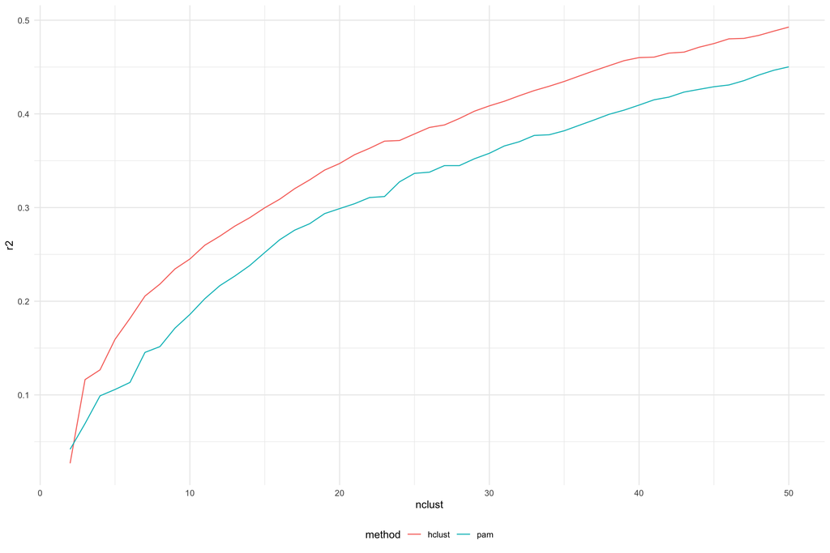

```r
running = F
if(running){
perm_alpha0 = permanova_custom(
  list_with_clusters = list_with_clusters_alpha0,
  ait_distMatrix = inducedDist_$normalizedAitDist,
  B = 1000)
saveRDS(perm_alpha0,file = paste0(savingdir,'/','perm_alpha0'))
}
perm_alpha0 <- readRDS(paste0(savingdir,'/','perm_alpha0'))


df_permanova <- plyr::ldply(perm_alpha0$hclust, function(el){
  return(data.frame(nclust = el$nclust[1], pvalue = el$`Pr(>F)`[1], r2 = el$R2[1]))
}, .id = "nclust")

df_permanova2 <- plyr::ldply(perm_alpha0$pam, function(el){
  return(data.frame(nclust = el$nclust[1], pvalue = el$`Pr(>F)`[1], r2 = el$R2[1]))
}, .id = "nclust")


df_perm = bind_rows(
  df_permanova %>% mutate(method='hclust'),
  df_permanova2 %>% mutate(method='pam'),
)

df_perm %>%
  ggplot(aes(x=nclust,y=r2,group=method,color=method))+
  geom_line()+
  theme_minimal()+
  theme(legend.position = 'bottom')
```

**Alpha = 0.1**

**Permanova**

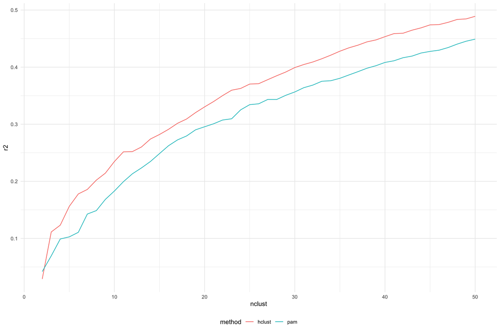

```r
running = F
if(running){
perm_alpha0.10 = permanova_custom(
  list_with_clusters = list_with_clusters_alpha0.10,
  ait_distMatrix = inducedDist_$normalizedAitDist,
  B = 1000)
saveRDS(perm_alpha0.10,file = paste0(savingdir,'/','perm_alpha0.10'))
}
perm_alpha0.10 <- readRDS(paste0(savingdir,'/','perm_alpha0.10'))


df_permanova <- plyr::ldply(perm_alpha0.10$hclust, function(el){
  return(data.frame(nclust = el$nclust[1], pvalue = el$`Pr(>F)`[1], r2 = el$R2[1]))
}, .id = "nclust")

df_permanova2 <- plyr::ldply(perm_alpha0.10$pam, function(el){
  return(data.frame(nclust = el$nclust[1], pvalue = el$`Pr(>F)`[1], r2 = el$R2[1]))
}, .id = "nclust")


df_perm = bind_rows(
  df_permanova %>% mutate(method='hclust'),
  df_permanova2 %>% mutate(method='pam'),
)

df_perm %>%
  ggplot(aes(x=nclust,y=r2,group=method,color=method))+
  geom_line()+
  theme_minimal()+
  theme(legend.position = 'bottom')
```

**Alpha = 0.25**

**Permanova**

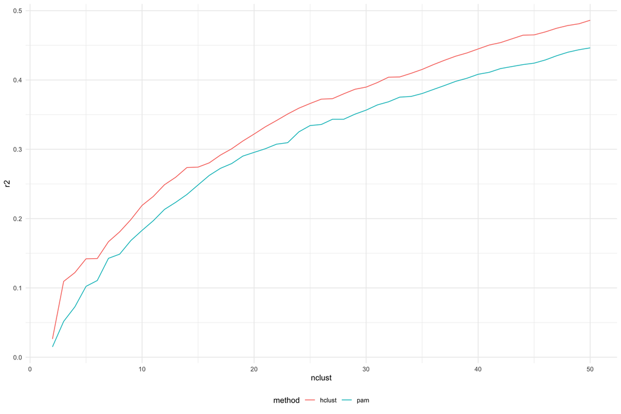

```r
running = F
if(running){
perm_alpha0.25 = permanova_custom(
  list_with_clusters = list_with_clusters_alpha0.25,
  ait_distMatrix = inducedDist_$normalizedAitDist,
  B = 1000)
saveRDS(perm_alpha0.25,file = paste0(savingdir,'/','perm_alpha0.25'))
}
perm_alpha0.25 <- readRDS(paste0(savingdir,'/','perm_alpha0.25'))


df_permanova <- plyr::ldply(perm_alpha0.25$hclust, function(el){
  return(data.frame(nclust = el$nclust[1], pvalue = el$`Pr(>F)`[1], r2 = el$R2[1]))
}, .id = "nclust")

df_permanova2 <- plyr::ldply(perm_alpha0.25$pam, function(el){
  return(data.frame(nclust = el$nclust[1], pvalue = el$`Pr(>F)`[1], r2 = el$R2[1]))
}, .id = "nclust")


df_perm = bind_rows(
  df_permanova %>% mutate(method='hclust'),
  df_permanova2 %>% mutate(method='pam'),
)

df_perm %>%
  ggplot(aes(x=nclust,y=r2,group=method,color=method))+
  geom_line()+
  theme_minimal()+
  theme(legend.position = 'bottom')
```

**Alpha = 0.5**

**Permanova**

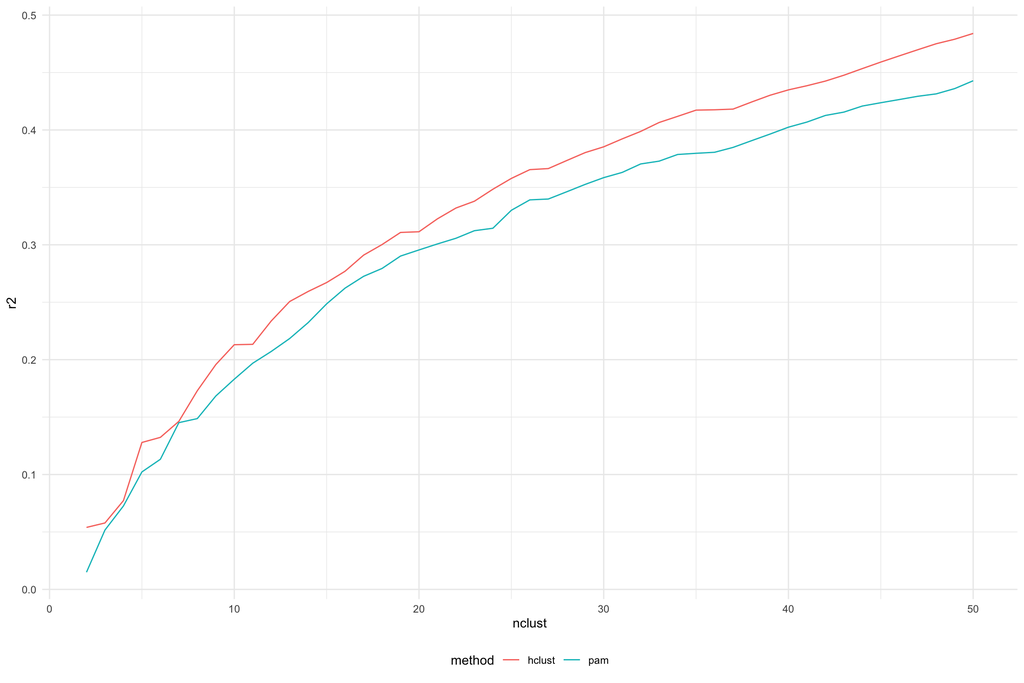

```r
running = F
if(running){
perm_alpha0.50 = permanova_custom(
  list_with_clusters = list_with_clusters_alpha0.50,
  ait_distMatrix = inducedDist_$normalizedAitDist,
  B = 1000)
saveRDS(perm_alpha0.50,file = paste0(savingdir,'/','perm_alpha0.50'))
}
perm_alpha0.50 <- readRDS(paste0(savingdir,'/','perm_alpha0.50'))


df_permanova <- plyr::ldply(perm_alpha0.50$hclust, function(el){
  return(data.frame(nclust = el$nclust[1], pvalue = el$`Pr(>F)`[1], r2 = el$R2[1]))
}, .id = "nclust")

df_permanova2 <- plyr::ldply(perm_alpha0.50$pam, function(el){
  return(data.frame(nclust = el$nclust[1], pvalue = el$`Pr(>F)`[1], r2 = el$R2[1]))
}, .id = "nclust")


df_perm = bind_rows(
  df_permanova %>% mutate(method='hclust'),
  df_permanova2 %>% mutate(method='pam'),
)

df_perm %>%
  ggplot(aes(x=nclust,y=r2,group=method,color=method))+
  geom_line()+
  theme_minimal()+
  theme(legend.position = 'bottom')
```